# Selection analyses on common vs rare human population variants using dNdScv

Federico Abascal

29/09/2019

### Introduction

This exercise shows how to run **dndscv** with human population variants. We will compare the intensity of selection in common and rare variants, defined as those with allele frequencies (AF) higher or lower than 0.005, respectively.

Something to think before doing the exercise: What global dN/dS values do you expect for common and rare variants? Would they be different? Higher or lower than 1?

Note: running dndscv for these large matrices takes quite long (30’-1h)

```r
library("dndscv")
```

#### Load the mutation data

For this study we need the following files: **1000g-common.tsv** and **1000g-rare.tsv**. Save them in a folder of your computer and set the working directory accordingly

```r
working_directory = "/Users/fa8/Documents/Presentaciones/Romania/tutorial_and_mutation_datasets"
setwd(working_directory)
```

Load variants:

```r
var_common = read.table("1000g-common.tsv",sep="\t",stringsAsFactors=F,header=T)
var_rare   = read.table("1000g-rare.tsv",  sep="\t",stringsAsFactors=F,header=T)
```

#### Run dndscv:

```r
dnds_1000g_common = dndscv(var_common,max_coding_muts_per_sample=Inf,max_muts_per_gene_per_sample=Inf)
dnds_1000g_rare   = dndscv(var_rare,max_coding_muts_per_sample=Inf,max_muts_per_gene_per_sample=Inf)
```

By default max_muts_per_gene_per_sample=3 and max_coding_muts_per_sample=3000, to remove hypermutators and not give too much weight to a sample having too many mutations in a given gene. Here we disable these thresholds because variants don’t belong to particular samples

#### Overall, which type of selection dominates, positive or negative?

Common variants

```r
dnds_1000g_common$globaldnds
```

```
##      name        mle      cilow    cihigh
## wmis wmis 0.42602387 0.42067921 0.4314364
## wnon wnon 0.09820318 0.09012964 0.1069999
## wspl wspl 0.13712954 0.12631628 0.1488685
## wtru wtru 0.11538996 0.10871975 0.1224694
## wall wall 0.40417528 0.39914181 0.4092722
```

Rare variants

```r
dnds_1000g_rare$globaldnds
```

```
##      name       mle     cilow    cihigh
## wmis wmis 0.7410709 0.7376476 0.7445101
## wnon wnon 0.3139965 0.3080077 0.3201017
## wspl wspl 0.3824392 0.3740788 0.3909865
## wtru wtru 0.3403635 0.3353982 0.3454024
## wall wall 0.7102140 0.7069633 0.7134797
```

#### Plot global dn/dS results

A simple plot:

[figure not shown]

```r
barplot(c(dnds_1000g_rare$globaldnds["wall","mle"],dnds_1000g_common$globaldnds["wall","mle"]),
        ylim=c(0,1),names.arg=c("Rare","Common"),main="1000G variants",ylab="Global dN/dS (missense)")
```

A more elaborate plot:

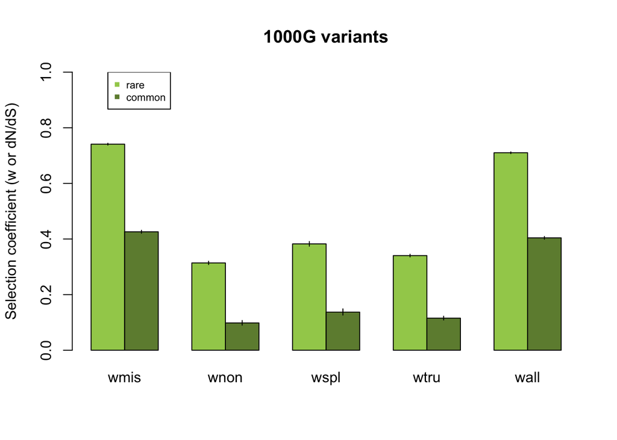

```r
bar = barplot(t(cbind(dnds_1000g_rare$globaldnds[,"mle"], dnds_1000g_common$globaldnds[,"mle"])),beside=T,names.arg=rownames(dnds_1000g_rare$globaldnds),
              ylab="Selection coefficient (w or dN/dS)",ylim=c(0,1),main="1000G variants",col=c("darkolivegreen3","darkolivegreen4"))
segments(bar[1,],dnds_1000g_rare$globaldnds[,"cilow"],bar[1,],dnds_1000g_rare$globaldnds[,"cihigh"])
segments(bar[2,],dnds_1000g_common$globaldnds[,"cilow"],bar[2,],dnds_1000g_common$globaldnds[,"cihigh"])
legend(bar[1,1],1,legend=c("rare","common"),pch=15,col=c("darkolivegreen3","darkolivegreen4"),cex=.7)
```

It is clear that negative selection is strong for all kind of variants (missense, nonsense and splicing).

Selection is weaker on low frequency variants, as expected (*mutations having an impact are under negative selection and have less chances of reaching high frequencies in the population*).